# Chapter 2 Exercises

Carilli

August 28, 2020

## Exercise 1

### Data

Read the data

```r
donuts <-
here::here("data", "DonutDataX.csv") %>%
  read_csv()
```

We can use `glimpse()` to get information about each variable

```r
donuts %>%
  glimpse()
```

```
Rows: 13
Columns: 6
$ name       <chr> "Homer", "Marge", "Lisa", "Bart", "ComicBookGuy", "Mr Bu...
$ donutsx    <chr> "14", "0", "0", "5", "20", "0.75", "0.25", "16", "3", "2...
$ weightx    <dbl> 275, 141, 70, 75, 310, 80, 160, 263, 205, 185, 170, 1550...
$ childx     <dbl> 0, 0, -1, -1, 0, 0, 0, 0, 0, 0, 0, 0, 0
$ malex      <dbl> 0, 1, 1, 0, 0, 0, 0, 0, 0, 0, 0, 1, 1
$ donutsXnew <dbl> 14.00, 0.00, 0.00, 5.00, 20.00, 0.75, 0.25, 16.00, 3.00,...
```

### donutsx

We see vector type for each variable. *donutsx* is a character vector and it should be a numeric vector. Let’s `pull` *donutsx*

```r
donuts %>%
  pull(donutsx)
```

```
 [1] "14"   "0"    "0"    "5"    "20"   "0.75" "0.25" "16"   "3"    "2"
[11] "0.8"  "five" "4"
```

```r
#  or

donuts$donutsx
```

```
 [1] "14"   "0"    "0"    "5"    "20"   "0.75" "0.25" "16"   "3"    "2"
[11] "0.8"  "five" "4"
```

We can see the 12<sup>th</sup> observation is “five” and should be 5. So we will change the observation from “five” to 5 and coerce *donutsx* to a numeric vector.

```r
donuts$donutsx[12] <- 5
donuts$donutsx <- as.numeric(donuts$donutsx)
```

### weightx

We can use `DT:datatable` to look at the data.

```r
donuts %>%
  DT::datatable()
```

|  | name | donutsx | weightx | childx | malex | donutsXnew |
| --- | --- | --- | --- | --- | --- | --- |
| 1 | Homer | 14 | 275 | 0 | 0 | 14 |
| 2 | Marge | 0 | 141 | 0 | 1 | 0 |
| 3 | Lisa | 0 | 70 | -1 | 1 | 0 |
| 4 | Bart | 5 | 75 | -1 | 0 | 5 |
| 5 | ComicBookGuy | 20 | 310 | 0 | 0 | 20 |
| 6 | Mr Burns | 0.75 | 80 | 0 | 0 | 0.75 |
| 7 | Smithers | 0.25 | 160 | 0 | 0 | 0.25 |
| 8 | Chief Wiggum | 16 | 263 | 0 | 0 | 16 |
| 9 | Principal Skinner | 3 | 205 | 0 | 0 | 3 |
| 10 | Rev. Lovejoy | 2 | 185 | 0 | 0 | 2 |

[output cut: 3 more lines]

If the problem is not immediately obvious, we could try a visualization like a boxplot

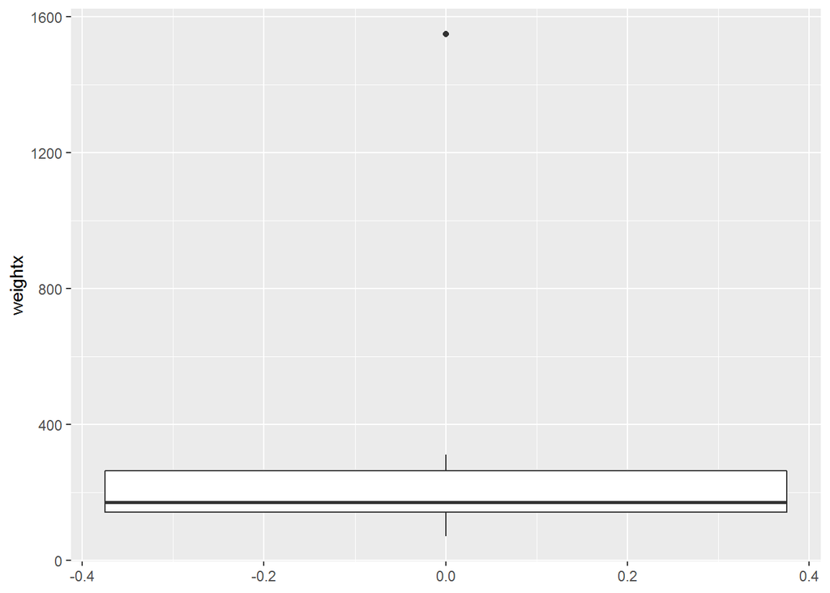

```r
donuts %>%
  ggplot(aes(y = weightx)) +
  geom_boxplot()
```

```r
which(donuts$weightx == 1550)
```

```
[1] 12
```

Let’s fix it.

```r
donuts$weightx[which(donuts$weightx == 1550)] <- 155

donuts$weightx
```

```
 [1] 275 141  70  75 310  80 160 263 205 185 170 155 145
```

### childx

We saw in the table above that while Bart and Lisa are children they are coded as -1, that should be 1

```r
donuts$childx <- donuts$childx * (-1)

donuts$childx
```

```
 [1] 0 0 1 1 0 0 0 0 0 0 0 0 0
```

### malex

```r
donuts %>%
  arrange(desc(malex))
```

| name | donutsx | weightx | childx | malex | donutsXnew |
| --- | --- | --- | --- | --- | --- |
| Marge | 0.00 | 141 | 0 | 1 | 0.00 |
| Lisa | 0.00 | 70 | 1 | 1 | 0.00 |
| Patty | 5.00 | 155 | 0 | 1 | 5.00 |
| Selma | 4.00 | 145 | 0 | 1 | 4.00 |
| Homer | 14.00 | 275 | 0 | 0 | 14.00 |
| Bart | 5.00 | 75 | 1 | 0 | 5.00 |
| ComicBookGuy | 20.00 | 310 | 0 | 0 | 20.00 |
| Mr Burns | 0.75 | 80 | 0 | 0 | 0.75 |
| Smithers | 0.25 | 160 | 0 | 0 | 0.25 |
| Chief Wiggum | 16.00 | 263 | 0 | 0 | 16.00 |

[output cut: 3 more lines]

We see that Marge, Lisa, Patty, and Selma are coded as 1 and the men are coded as 0. We change this in two ways, rename the variable to *femalex* or subtract *malex* from 1.

```r
donuts$malex <- 1 - donuts$malex

donuts %>%
  arrange(desc(malex))
```

| name | donutsx | weightx | childx | malex | donutsXnew |
| --- | --- | --- | --- | --- | --- |
| Homer | 14.00 | 275 | 0 | 1 | 14.00 |
| Bart | 5.00 | 75 | 1 | 1 | 5.00 |
| ComicBookGuy | 20.00 | 310 | 0 | 1 | 20.00 |
| Mr Burns | 0.75 | 80 | 0 | 1 | 0.75 |
| Smithers | 0.25 | 160 | 0 | 1 | 0.25 |
| Chief Wiggum | 16.00 | 263 | 0 | 1 | 16.00 |
| Principal Skinner | 3.00 | 205 | 0 | 1 | 3.00 |
| Rev. Lovejoy | 2.00 | 185 | 0 | 1 | 2.00 |
| Ned Flanders | 0.80 | 170 | 0 | 1 | 0.80 |
| Marge | 0.00 | 141 | 0 | 0 | 0.00 |

[output cut: 3 more lines]

## Exercise 2

### Data

```r
oly <-
  here::here("data", "olympics_hw.csv") %>%
  read_csv() %>%
  janitor::clean_names()
```

### (a)

```r
oly %>%
  select(medals, athletes, gdp) %>%
  summary()
```

```
     medals        athletes          gdp
 Min.   : 0.0   Min.   :  0.0   Min.   : 0.0
 1st Qu.: 0.0   1st Qu.:  0.0   1st Qu.: 0.1
 Median : 0.0   Median :  2.0   Median : 0.4
 Mean   : 1.8   Mean   : 18.2   Mean   : 1.2
 3rd Qu.: 0.0   3rd Qu.: 13.0   3rd Qu.: 1.5
 Max.   :37.0   Max.   :230.0   Max.   :14.5
                                NA's   :156
```

```r
oly %>%
  select(medals, athletes, gdp) %>%
  summarytools::descr()
```

```
Descriptive Statistics
oly
N: 1122

                    athletes      gdp    medals
----------------- ---------- -------- ---------
             Mean      18.17     1.17      1.75
          Std.Dev      36.88     1.81      5.17
              Min       0.00     0.01      0.00
               Q1       0.00     0.12      0.00
           Median       2.00     0.38      0.00
               Q3      13.00     1.51      0.00
              Max     230.00    14.52     37.00
              MAD       2.97     0.49      0.00
              IQR      13.00     1.39      0.00
               CV       2.03     1.55      2.95
         Skewness       2.79     3.07      3.78
      SE.Skewness       0.07     0.08      0.07
         Kurtosis       8.42    12.82     15.19
          N.Valid    1122.00   966.00   1122.00
        Pct.Valid     100.00    86.10    100.00
```

### (b)

```r
oly %>%
  select(country, year, medals, athletes, gdp) %>%
  slice(n = 1:5)
```

| country | year | medals | athletes | gdp |
| --- | --- | --- | --- | --- |
| Albania | 1980 | 0 | 0 | NA |
| Albania | 1984 | 0 | 0 | 0.0641 |
| Albania | 1988 | 0 | 0 | 0.0637 |
| Albania | 1992 | 0 | 0 | 0.0206 |
| Albania | 1994 | 0 | 0 | 0.0587 |

### (c)

```r
n_distinct(oly$year)
```

```
[1] 10
```

```r
oly %>%
  group_by(year) %>%
  count()
```

| year | n |
| --- | --- |
| 1980 | 117 |
| 1984 | 117 |
| 1988 | 117 |
| 1992 | 113 |
| 1994 | 110 |
| 1998 | 110 |
| 2002 | 110 |
| 2006 | 110 |
| 2010 | 109 |
| 2014 | 109 |

### (d)

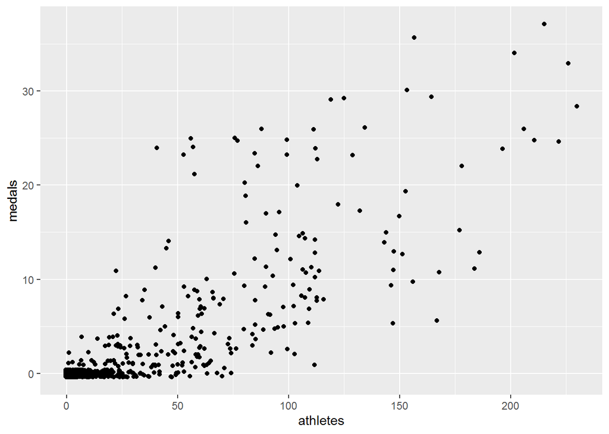

```r
oly %>%
  ggplot(aes(x = athletes, medals)) +
  geom_jitter()
```

### (e)

More athletes means more opportunity to win medals. The presence of an athlete is necessary to win a medal.

### (f)

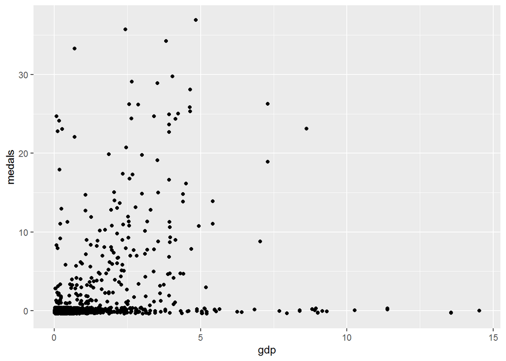

```r
oly %>%
  ggplot(aes(x = gdp, y = medals)) +
  geom_jitter()
```

### (g)

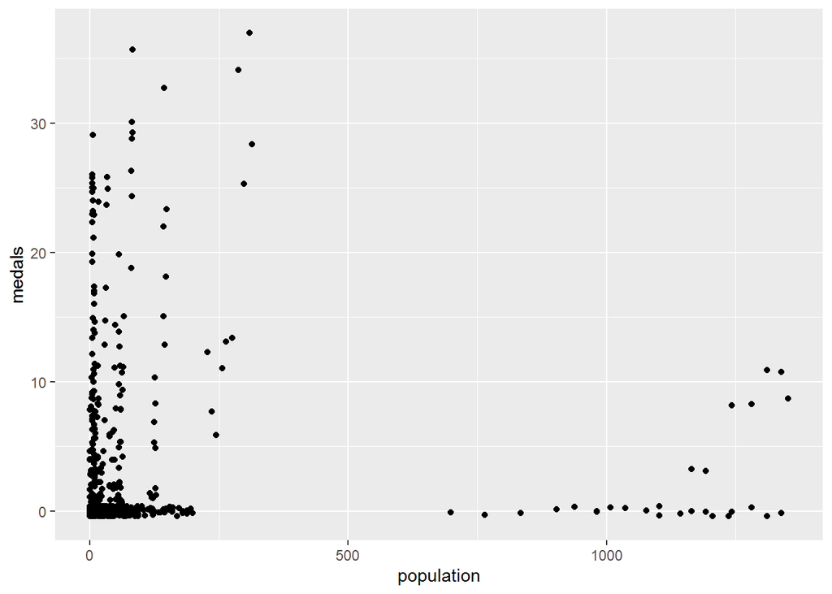

```r
oly %>%
  ggplot(aes(x = population, y = medals)) +
  geom_jitter()
```

### (h)

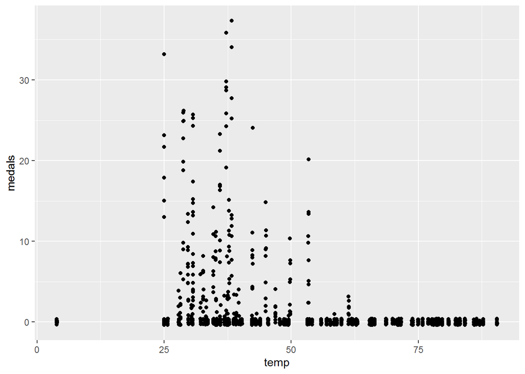

```r
oly %>%
  ggplot(aes(x = temp, y = medals)) +
  geom_jitter()
```

## Exercise 3

### Data

```r
hw <-
here::here("data", "HeightWage_MenWomenUS_HW.csv") %>%
  read_csv() %>%
  janitor::clean_names()
```

### (a)

```r
hw %>%
  select(wage96, height81, height85, siblings) %>%
  summarytools::descr() %>%
  summarytools::tb()
```

| variable | mean | sd | min | q1 | med | q3 | max | mad | iqr | cv | skewness | se.skewness | kurtosis | n.valid | pct.valid |
| --- | --- | --- | --- | --- | --- | --- | --- | --- | --- | --- | --- | --- | --- | --- | --- |
| height81 | 67.01 | 4.07 | 48 | 64.00 | 67.0 | 70.0 | 83 | 4.45 | 6.00 | 0.0607 | 0.0785 | 0.0222 | -0.428 | 12143 | 95.7 |
| height85 | 67.08 | 4.11 | 48 | 64.00 | 67.0 | 70.0 | 81 | 4.45 | 6.00 | 0.0613 | 0.0441 | 0.0235 | -0.387 | 10863 | 85.6 |
| siblings | 3.84 | 2.65 | -3 | 2.00 | 3.0 | 5.0 | 29 | 1.48 | 3.00 | 0.6899 | 1.3448 | 0.0217 | 2.963 | 12686 | 100.0 |
| wage96 | 14.18 | 27.37 | 0 | 6.74 | 10.8 | 16.2 | 1533 | 6.72 | 9.47 | 1.9307 | 32.2570 | 0.0294 | 1541.293 | 6930 | 54.6 |

### (b)

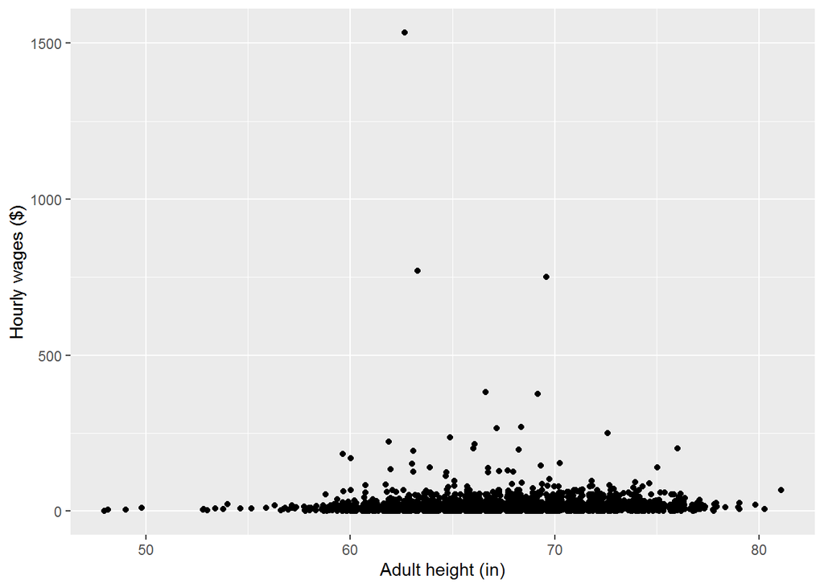

```r
hw %>%
  ggplot(aes(x = height85, y = wage96)) +
  geom_jitter() +
  labs(x = "Adult height (in)", y = "Hourly wages ($)")
```

### (c)

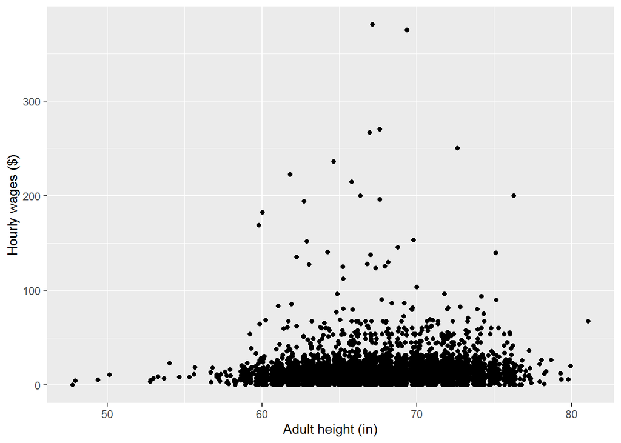

```r
hw %>%
  filter(wage96 < 500) %>%
  ggplot(aes(x = height85, y = wage96)) +
  geom_jitter() +
  labs(x = "Adult height (in)", y = "Hourly wages ($)")
```

### (d)

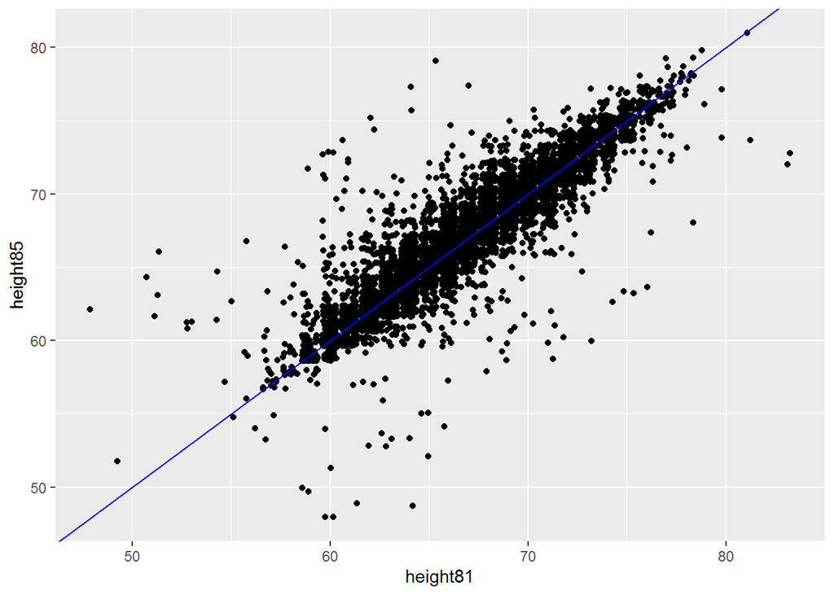

```r
hw %>%
  ggplot(aes(x = height81, y = height85)) +
  geom_jitter() +
  geom_abline(slope = 1, color ="blue")
```

## Exercise 4

### Data

```r
anscome <-
here::here("data", "AnscombesQuartet.csv") %>%
  read_csv()
```

### (a)

```r
anscombe %>%
  summarytools::descr(stats = list("mean", "sd"))
```

```
Descriptive Statistics
anscombe
N: 11

                  x1     x2     x3     x4     y1     y2     y3     y4
------------- ------ ------ ------ ------ ------ ------ ------ ------
         Mean   9.00   9.00   9.00   9.00   7.50   7.50   7.50   7.50
      Std.Dev   3.32   3.32   3.32   3.32   2.03   2.03   2.03   2.03
```

```r
anscombe %>%
  summarize(across(everything(), list(mean = mean, variance = var))) %>%
  pivot_longer(everything(),names_to = "measure", values_to = "value")
```

| measure | value |
| --- | --- |
| x1_mean | 9.00 |
| x1_variance | 11.00 |
| x2_mean | 9.00 |
| x2_variance | 11.00 |
| x3_mean | 9.00 |
| x3_variance | 11.00 |
| x4_mean | 9.00 |
| x4_variance | 11.00 |
| y1_mean | 7.50 |
| y1_variance | 4.13 |

[output cut: 6 more lines]

### (b)

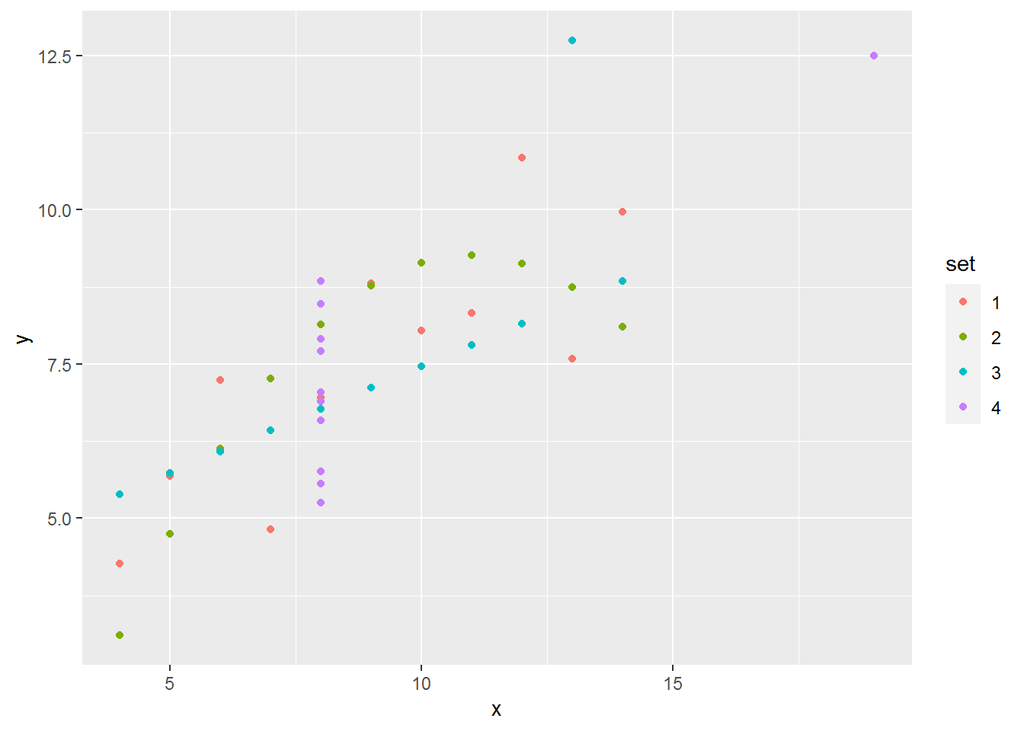

```r
anscombe %>%
  pivot_longer(everything(),
   names_to = c(".value", "set"),
   names_pattern = "(.)(.)"
 ) %>%
  ggplot(aes(x = x, y = y, color = set)) +
  geom_point()
```